# Learning and Analytics

[Unsupervised learning is a form of descriptive analytics. Predictive analytics aims to estimate outcomes from current data. Supervised learning is a kind of predictive analytics. Finally, prescriptive analytics guides actions to take in order to guarantee outcomes.](http://www.argmin.net/2018/01/29/taxonomy/)

There is another trichotomy in statistics `descriptive analysis`, `exploratory analysis`, `inferential analysis`.

## Unsupervised Learning

### Clustering

There are two different contexts in clustering, depending on how the entities to be clustered are organized. In some cases one starts from an **internal representation** of each entity (typically an $M$-dimensional vector $x_i$ assigned to entity $i$) and derives mutual dissimilarities or mutual similarities from the internal representation. In this case one can derive prototypes (or centroids) for each cluster, for example by averaging the characteristics of the contained entities (the vectors). In other cases only an **external representation** of dissimilarities is available and the resulting model is an **undirected and weighted graph** of entities connected by edges. From https://www.intelligent-optimization.org/LIONbook/.[^13] * **The external representation of dissimilarity will be discussed in** Graph Algorithm**.

- http://sklearn.apachecn.org/cn/0.19.0/modules/clustering.html
- https://www.wikiwand.com/en/Cluster_analysis
- https://www.toptal.com/machine-learning/clustering-algorithms
- https://blog.csdn.net/xiaojimanman/article/details/44977889
- https://github.com/hankcs/HanLP/wiki/%E6%96%87%E6%9C%AC%E8%81%9A%E7%B1%BB
- http://www.charuaggarwal.net/text-cluster.pdf
- https://www.tutorialspoint.com/data_mining/dm_cluster_analysis.htm

#### K-means cluster

The hard clustering problem consists of partitioning the entities ${D}$ into ${k}$ disjoint subsets $C = \{C_1, \cdots, C_k\}$ to reach the following objectives:

- Minimization of the average intra-cluster dissimilarities;
- Maximization of inter-cluster distance.

K-means is also called **Lloyd鈥檚 algorithm**. It is a prototype-based clustering method.

> - Set the class number $k$ and initialize the centers of the classes $\{c_i, c_2, \dots, c_k\}$.
> - Split the data set to $k$ classes by the shortest distance to the center:
>   $$\arg\min_{i}\|x-c_i\|$$
> - Update the center of the class $i$:
>   $$c_i\leftarrow \frac{\sum_{x}\mathbb{I}(x\in \text{Class i})x}{\sum_{x}\mathbb{I}(x\in \text{Class i})}$$
> - Until the stop criterion is satisfied.

The indicator function $\mathbb{I}(x\in\text{Class i})$ is defined as
$$\mathbb{I}(x\in\text{Class i})=
\begin{cases}
1, \text{if $x\in\text{Class i}$} \\
0, \text{otherwise}.
\end{cases}$$

In optimization form, it is to minimize the following objective function `distortion measure`:

$$J = \sum_{n=1}^{N}\sum_{k=1}^{K} \mathbb{I}_{nk}\|x_n-\mu_k\|^2$$
where $\mathbb{I}_{nk}$ is a binary Dirac function.

After initializing the $K$ and $\mu_k$, we fix $\mu_k$ and optimize the objective function with respect to $\mathbb{I}_{nk}$:

$$\mathbb{I}(n,k)=
\begin{cases}
1, \text{if $k=\arg\min_{j} \|x_n-\mu_j\|^2$} \\
0, \text{otherwise}.
\end{cases}$$

Then we fix $\mathbb{I}_{nk}$ and optimize the objective function with respect to $\mu_k$: setting $\frac{\partial J}{\partial \mu_k} = 0$, we obtain
$$\mu_k = \frac{\sum_n \mathbb{I}_{nk}x_n}{\sum_n \mathbb{I}_{nk}}.$$

In the first procedure, it is supposed to maximize the inter-cluster dissimilarity; The second procedure, it is supposed to minimize the intra-cluster distance.

- https://www.wikiwand.com/en/K-means_clustering
- [Visualizing K-Means Clustering](http://web.stanford.edu/class/ee103/visualizations/kmeans/kmeans.html)

#### Mixture Model and EM

In K-means, we compute the mean or average of the samples in a class to update the centroid. It is interesting to observe the “variance” or “range” of the clusters. The samples in the same cluster may be generated by the same pattern or distribution.

In statistics, the mixture distribution can describe complicated probability distribution such as [Gaussian mixture model](http://blog.pluskid.org/?p=39).

Suppose that the population is distributed in the mixture of Gaussian distribution:
$$P(x) = \sum_{k=1}^{K}p(k) p(x|k)
= \sum_{k=1}^{K}\pi(k) N(x|\mu_k,\Sigma_k)$$
where the discrete distribution of clustering $\sum_{k=1}^{K}\pi(k) = 1, \pi(k)\geq 0\quad\forall k$ and $N(x|\mu_k,\Sigma_k)$ is the multivariate normal(Gaussian) distribution.

Like k-means clustering, the class number ${k}$ is set manually and the $\mu_k.\Sigma_k$ are to estimate.

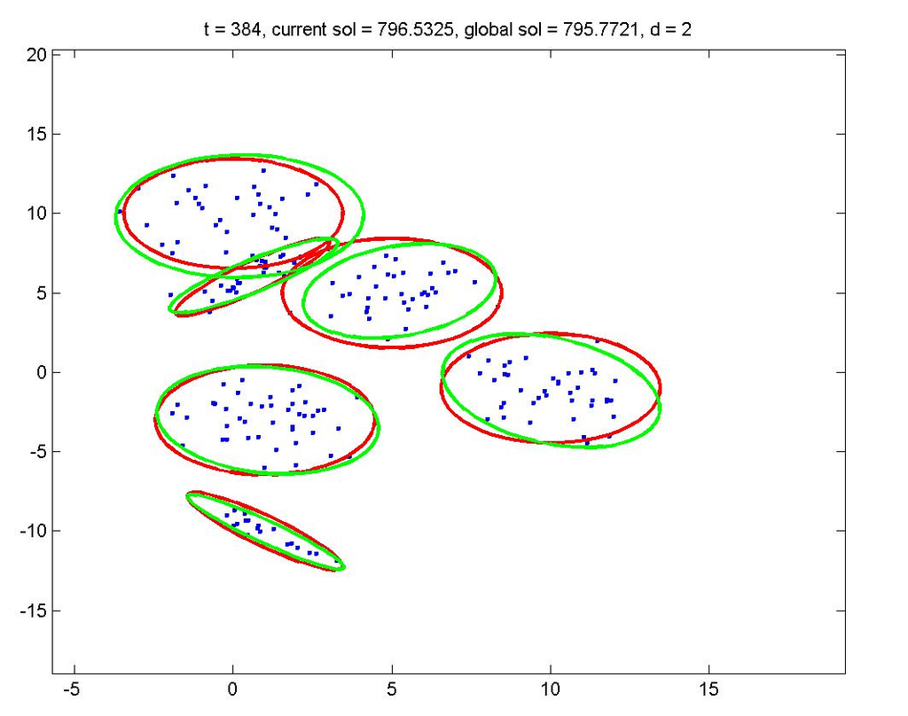

The likelihood of the observed random variables is given by
$$\prod_{i=1}^{N} P(x_i)= \prod_{i=1}^{N} \sum_{k=1}^{K}\pi(k) N(x_i |\mu_k,\Sigma_k)$$

so that the log-likelihood function is given by
$$\log\prod_{i}^{N} P(x_i)= \sum_{i}^{N} \log[\sum_{k=1}^{K}\pi(k) N(x_i|\mu_k,\Sigma_k)].$$

In **The Nature of Statistical Learning**, the author gives an example of Gaussian mixture that cannot be estimated via maximum likelihood estimation.

Bishop introduces clustering in Bayesian perspective : > An elegant and powerful method for finding maximum likelihood solutions for models with latent variables is called the expectation-maximization algorithm, or EM algorithm.

Let us begin by writing down the conditions that must be satisfied at a maximum of the likelihood function. Setting the derivatives of log-likelihood function with respect to the means $\mu_k$ of the Gaussian components to zero, we obtain
$$0 = \sum_{i}^{N} \frac{\pi(k) N(x_i |\mu_k, \Sigma_k) }{\sum_{k=1}^{K}\pi(k) N(x_i|\mu_k,\Sigma_k)} \Sigma_k(x_i - \mu_k)$$

And if we define $\gamma(z_{ik}) = \frac{\pi(k) N(x_i |\mu_k, \Sigma_k) }{\sum_{k=1}^{K}\pi(k) N(x_i|\mu_k,\Sigma_k)}$, it converts to
$$0 = \sum_{i}^{N} \gamma(z_{ik}) \Sigma_k(x_i - \mu_k)$$
Multiplying by inverse of matrix $\Sigma_k$ and rearranging we obtain

$$\mu_k = \frac{1}{N_k}\sum_{i=1}^{N}\gamma(z_{ik}) \Sigma_k x_i$$

where we define $N_k = \sum_{i}\gamma(z_{ik})$.

And similarly, we can obtain that
$$\Sigma_k = \frac{1}{N_k}\sum_{i=1}^{N} \gamma(z_{ik}) (x_i - \mu_k)(x_i - \mu_k)^T.$$

The $\pi_k$ as the same role in k-means is estimated via Lagrange multiplier and maximizing the following quantity

$$L(\mu, \Sigma, \lambda)= \sum_{i}^{N} \log[\sum_{k=1}^{K}\pi(k) N(x_i|\mu_k,\Sigma_k)] + \lambda (\sum_{k=1}^{K}\pi(k)-1).$$

By setting the derivatives to zeros, we obtain

$$0 = \sum_{i}^{N} [\frac{ N(x_i |\mu_k, \Sigma_k) }{\sum_{k=1}^{K}\pi(k) N(x_i|\mu_k,\Sigma_k)} + \lambda]$$

Multiplying by inverse of matrix $\sum_{k=1}^{K}\pi(k) N(x_i|\mu_k,\Sigma_k)$ and rearranging, we gain that
$$\pi(k)=\frac{N_k}{N}.$$

#### K-medoids Clustering

`K-medoids Clustering` is the twin of the k-means clustering. Rather than using conventional mean/centroid, it uses medoids to represent the clusters. [The medoid is a statistic which represents that data member of a data set whose average dissimilarity to all the other members of the set is minimal.](https://www.wikiwand.com/en/Medoid)

Let $x_{1},x_{2},\cdots ,x_{n}$ be a set of ${\textstyle n}$ points in a space with a distance function ${d}$. `Medoid` is defined as

$$x_{\text{medoid}} = {\arg\min}_{y\in \{x_{1},x_{2},\cdots ,x_{n}\}} \sum _{i=1}^{n} d(y,x_{i}).$$

The simplified version is to compute the `median` of each attribute to approximate medoid instead of the optimization in the definition, where the dissimilarity function $d(y, x)=\| y-x\|_{1}$.

It also begins with randomly selecting k data items as initial medoids to represent the k clusters. All the other remaining items are included in a cluster which has its medoid closest to them. Thereafter a new medoid is determined which can represent the cluster better. All the remaining data items are yet again assigned to the clusters having closest medoid. In each iteration, the medoids alter their location. The method minimizes the sum of the dissimilarities between each data item and its corresponding medoid. This cycle is repeated till no medoid changes its placement. This marks the end of the process and we have the resultant final clusters with their medoids defined. ${K}$ clusters are formed which are centered around the medoids and all the data members are placed in the appropriate cluster based on nearest medoid.

- http://www.math.le.ac.uk/people/ag153/homepage/KmeansKmedoids/Kmeans_Kmedoids.html
- http://blog.pluskid.org/?p=40
- https://wireilla.com/ns/maths/Papers/3314ijscmc01.pdf

#### Hierarchical clustering

**Hierarchical clustering algorithms** are either top-down or bottom-up. These methods are based on the choice of distance measure or metric.

Bottom-up algorithms (*Agglomerative Hierarchical Clustering*) treat each document as a singleton cluster at the outset and then successively merge (or agglomerate) pairs of clusters until all clusters have been merged into a single cluster that contains all documents.

The algorithm works as follows:

- Put each data point in its own cluster.
- Identify the closest two clusters and combine them into one cluster.
- Repeat the above step until all the data points are in a single cluster.

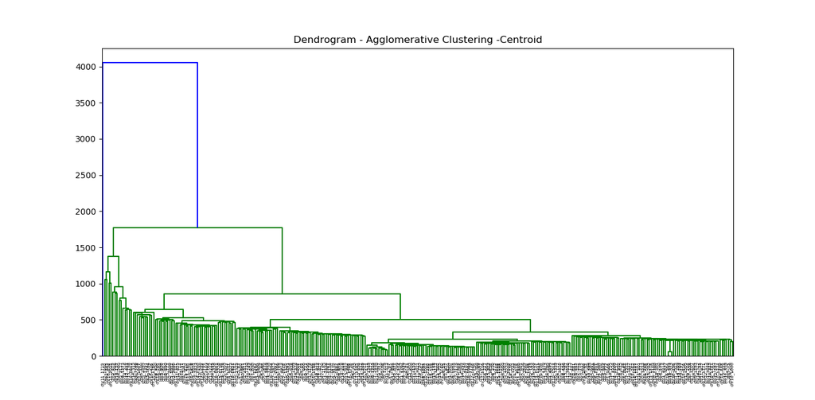

> The idea is to build a binary tree of the data that successively merges similar groups of points.

And we identify the closest two clusters by the `group similarity` of these clusters. There are three most popular choices of group similarity induced by a distance measure between points $d_{i,j}$:

- Single-linkage: the similarity of the closest pair: $d_{SL}(G, H) = \min_{i\in G, j\in H} d_{i,j}$;
- Complete linkage: the similarity of the furthest pair: $d_{SL}(G, H) = \max_{i\in G, j\in H} d_{i,j}$;
- Group average: the average similarity between groups: $d_{SL}(G, H) = \frac{1}{|G||H|}\sum_{i\in G, j\in H} d_{i,j}$, where $|G|,|H|$ is the number of member in cluster ${G}$ and ${H}$, respectively.

$\color{quad}{PS}$: the distance or similarity here is not metric in mathematics. The measures of distance are supposed to be non-negative and semi-linear so that

1. $d(x,y)\geq 0$ and $d(x,y)=0$ if and only if $x=y$;
2. $d(\alpha x,\alpha y) = |\alpha| d(x, y)$.

In fact, we can use Bregman divergence to cluster.

*Divisive Hierarchical Clustering* begin with the entire data set as a single cluster, and recursively divide one of the existing clusters into two daughter clusters at each iteration in a top-down fashion. The split is chosen to produce two new groups with the largest `between-group dissimilarity`.

Its template is described as :

1. Put all objects in one cluster;
2. Repeat until all cluster are singletons:
   - 1. choose a cluster to split;
   - 2. replace the chosen cluster with the sub-clusters.

It begins by placing all observations in a single cluster G. It then chooses that observation whose average dissimilarity from all the other observations is largest. This observation forms the first member of a second cluster H. At each successive step that observation in G whose average distance from those in H, minus that for the remaining observations in G is largest, is transferred to H. This continues until the corresponding difference in averages becomes negative.

And it is recommended the diameter $D_G$ of a group of observations defined as the largest dissimilarity among its members
$$D_G = \max_{i,j\in G}d_{i,j}$$

- http://www.cs.princeton.edu/courses/archive/spr08/cos435/Class_notes/clustering4.pdf
- http://www.ijcstjournal.org/volume-5/issue-5/IJCST-V5I5P2.pdf
- https://nlp.stanford.edu/IR-book/html/htmledition/divisive-clustering-1.htmls

#### DBSCAN

Density-based spatial clustering of applications with noise (DBSCAN) is a data clustering algorithm proposed by Martin Ester, Hans-Peter Kriegel, J枚rg Sander and Xiaowei Xu in 1996.

- All points within the cluster are mutually density-connected.
- If a point is density-reachable from any point of the cluster, it is part of the cluster as well.

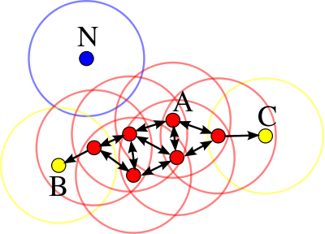

- https://www.wikiwand.com/en/DBSCAN
- http://www.cs.fsu.edu/~ackerman/CIS5930/notes/DBSCAN.pdf
- https://scikit-learn.org/stable/modules/generated/sklearn.cluster.DBSCAN.html
- https://blog.csdn.net/qq_40793975/article/details/82734297

#### Grid-based Clustering

A grid-based method quantizes ${D}$ into a finite number of cells forming a grid-structure, where the quantization process is usually performed in a multi-resolution style.

`Clustering based on Grid-Density and Spatial Partition Tree(CGDSPT)` - http://cucis.ece.northwestern.edu/publications/pdf/LiaLiu04A.pdf - https://blog.csdn.net/qq_40793975/article/details/82838253

#### Bi-clustering

It is from biological information.

Bi-clustering identifies groups of genes with similar/coherent expression patterns under a specific **subset** of the conditions. Clustering identifies groups of genes/conditions that show similar activity patterns under **all the set** of conditions/all the set of genes under analysis.

The matrix ${A}$ contains the rows index ${X}$ and columns index ${Y}$, whose element $a_{ij}$ is the expression level of gene ${i}$ under condition ${j}$ (quantity of mRNA) in biology. And the submatrix of ${A}$ is denoted by $A_{IJ}$ where $I\subset X, J\subset Y$.

A bicluster is defined as a submatrix spanned by a set of genes and a set of samples. Alternatively, a bicluster may be defined as the corresponding gene and sample subsets.

- http://www.cs.princeton.edu/courses/archive/spr05/cos598E/Biclustering.pdf
- https://cw.fel.cvut.cz/old/_media/courses/a6m33bin/biclustering.pdf
- http://www.kemaleren.com/post/an-introduction-to-biclustering/
- https://www.cs.tau.ac.il/~roded/articles/bicrev.pdf

#### Ensemble methods of Clusterings

- [Combining Multiple Clusterings Using Evidence Accumulation](https://ieeexplore.ieee.org/document/1432715/)

### Classification

Classification is a basic task in machine learning even in artificial intelligence. It is supervised with discrete or categorical desired labels. In statistics, some `regression methods` such as `logistic regression` is factually designed for classification tasks. It is one of the most fundamental and common tasks in machine learning.

Its inputs or the feature vector is always numerical $X\in\mathbb{R}^p$ and the output or prediction is assumed to be in some discrete space $\mathbb{Z}^d$.

- http://vision.stanford.edu/teaching/cs231n-demos/knn/
- https://en.wikipedia.org/wiki/Category:Classification_algorithms
- https://people.eecs.berkeley.edu/~jordan/classification.html

#### Recursive Partitioning

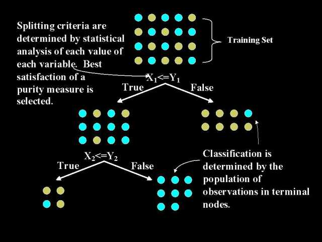

Recursive Partitioning

- http://ai-depot.com/Tutorial/DecisionTrees-Partitioning.html
- https://www.wikiwand.com/en/Recursive_partitioning
- [Model-Based Recursive Partitioning for Subgroup Analyses, Heidi Seibold, Achim Zeileis, Torsten Hothorn](https://www.degruyter.com/view/j/ijb.2016.12.issue-1/ijb-2015-0032/ijb-2015-0032.xml)

#### K-Nearest Neighbors

K-NN is simple to implement for high dimensional data. It is based on the assumption that the nearest neighbors are similar.

- Find the k-nearest neighbors $\{(p_1,d_0), \dots, (p_k,d_k)\}$ of the a given point $P_0$;
- Vote the label of the point $P_0$: $d_0=\max{d}$, where $d$ is the number of the desired label.

It is an example of distance-based learning methods. The neighbors are determined by the distance or similarity of the instances.

- https://www.wikiwand.com/en/K-nearest_neighbors_algorithm
- http://www.scholarpedia.org/article/K-nearest_neighbor

### Support Vector Machine

Support vector machine initially is a classifier for the linearly separate data set. It can extend to kernel methods.

Assume that we have a training set $D = \{(x_i,d_i)\}_{i=1}^n$, where $d_i$ is binary so that $d_i\in\{+1,-1\}$, and it is linearly separate. In another word, the set $\{x_{i_1}\}$ with label ${+1}$ and the set $\{x_{i_2}\}$ with label ${-1}$ are convex and disjoint so that there is a hyper-line $f(x)=\left< w, x \right> + b$ separating them:
$$d_i\cdot f(x_i) = d_i\cdot (\left< w, x \right> + b) \geq 0\quad \forall i.$$

If it is able to classify the training data set into 2 classes, the `perceptron` algorithms can replace it.

The problem is how to determine the parameters $w,b$, which can generalize to new data set without labels or predict the labels precisely and reliably. The key point is to find the point data $(x,d)$ makes $f(x)=d$ , which is called as `support vector`. And we call $\gamma_i = d_i\cdot f(x_i)$ `functional margin` then we would like to maximize the functional margin over the training data set:
$$\arg\max_{w, b} \overline{\gamma}\\
s.t.\quad d_i\cdot f(x_i) \geq 0$$
where $\overline{\gamma} = \min_{i}\gamma_i$. Suppose that $f(x) = \left< w_0, x \right> + b_0$ can separate the training data points:

$$\gamma_i = d_i \cdot (\left< w_0, x_i \right> + b_0)\geq 0\quad \forall i.$$
It is clear that
$$2\gamma_i = 2d_i \cdot (\left< w_0, x_i \right> + b_0)
\\= d_i \cdot (\left< 2w_0, x_i \right> + 2b_0)
\geq 0\quad \forall i.$$
The second equation is because of the linearity of inner product. In other words, $\stackrel{\sim}{f}(x) = \left< 2w_0, x \right> + 2b_0$ can separate the training data set. It comes to the conclusion that the problem to maximize the functional margin is not possible in theory if we do not constrain the parameters.

It is better to solve the following problem:
$$\arg\max_{w, b} \overline{\gamma}\\
s.t.\quad d_i\cdot f(x_i) \geq \overline{\gamma} \\
\|w\|_2 \leq c$$

The `geometric margins` of the point $(x, d)$ to the hyper-line $\left< w, x \right> + b$ is defined as
$$\frac{|\left< w, x \right> + b|}{\|w\|_2} .$$
In fact, it is the distance from the point ${x}$ to the hyper-line.

One natural alternative is to compute the distance from data point to the hyper-line:
$$\arg\max_{w, b} \frac{\overline{\gamma}}{\|w\|}\\
s.t.\quad d_i\cdot f(x_i) \geq \overline{\gamma}$$

And setting the shortest distance to 1: $\overline{\gamma} = 1$, the optimization problem is
$$\arg\max_{w, b} \frac{1}{\|w\|}\\
s.t.\quad d_i\cdot f(x_i) \geq 1.$$

Support Vector Machine

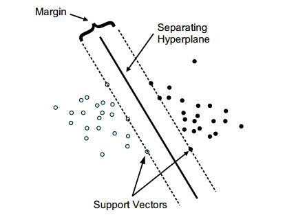

It can convert to a constrained optimization problem:

$$\min_{w, b} \frac{1}{2} {\|w\|}_2^2 \\
s.t.\qquad d_i(\left< w, x \right> + b) \geq 1$$

It is a convex quadratic programming(QP) problem. We can use [Lagrange multipliers method](https://www.svm-tutorial.com/2016/09/duality-lagrange-multipliers/) or ADMM(one augmented Lagrangian multiplier method).

The learning task reduces to minimization of the primal objective function
$$L = \frac{1}{2}\|w\|^2 -\sum_{i=1}^{n}\alpha_i (d_i(\left<w, x_i\right>+b)-1)$$
where $\alpha_i$ is Lagrange multiplier. Taking the derivatives with respect to ${b}$ and ${w}$ give:
$$\sum_{i=1}^{n}\alpha_i d_i = 0 \\
w = \sum_{i=1}^{n}\alpha_i d_i x_i$$

and resubstituting these expressions back in the primal gives the `Wolfe dual`:
$$\sum_{i=1}^{n}\alpha_i -\frac{1}{2} \sum_{i, J=1}^{n}\alpha_i \alpha_j d_i d_j \left<x_i, x_j\right>$$

which must be maximized with respect to the $\alpha_i$ subject to the constraints
$$\sum_{i=1}^{n}\alpha_i d_i = 0, \alpha_i \geq 0\quad \forall i.$$

Thus the classifier (hyper-line) is parameterized as
$$f(x)= \left< \sum_{i=1}^{n}\alpha_i d_i x_i, x\right> + b$$
where $\alpha_i \geq 0\quad\forall i$ is determined by optimizing the Wolfe dual.

It is data-dependent i.e., if we add a new data point the hyper-line may change. And it is not suitable to apply incremental or stochastic gradient method to learn the hyper-line.

The preliminary of SVM is that the training data is linearly separate. What if the data points in two class is nearly linearly separate as two interlocked gear, of which only few points cannot separated by a line.

To handle this case, we relax our constraints to require instead that $d_i(\left< w, x \right> + b) \geq 1 - \epsilon_i$. Of course, we want to keep the $\epsilon_i$ terms small, so we reformulate our optimization problem as follows:
$$\min_{w, b} \frac{1}{2} {\|w\|}_2^2 + C\sum_{i=1}^n \epsilon_i\\
s.t.\qquad d_i(\left< w, x \right> + b) \geq 1 - \epsilon_i.$$

Fix ${w}$, we have $\epsilon_i = \max \{0, 1-d_i \left<w, x_i\right>\}$. This equation ensures that $\epsilon_i$ is the smallest possible value that satisfies the ${i}$-th constraint. And we choose the optimal parameters ${w}^{\star}$:
$$w^{\star}=\arg\min_{w} \{ \frac{1}{2}\|w\|^2 + C\sum_{i=1}^{n}\max\{0, 1 - d_i\left<w,x_i\right>\} \}.$$

We continue our discussion of linear soft margin support vector machines. But first let us break down that phrase a little bit. * Linear because our classifier takes a linear combination of the input features and outputs the sign of the result. * Soft margin because we allow for some points to be located within the margins or even on the wrong side of the decision boundary. This was the purpose of introducing the ${\epsilon_i}$ terms. * Support vector machines because the final decision boundary depends only on a subset of the training data known as the support vectors.

The goal of `soft-margin` SVM is to choose ${w}$ so as to minimize the objective function $F: \mathbb{R}^d\to \mathbb{R}$ defined by
$$L(w)=\frac{1}{2}\|w\|^2 + C\sum_{i=1}^{n}\max\{0, 1 - d_i\left<w,x_i\right>\}$$

where the `hinge loss`, $\max\{0, 1 - d_i\left<w,x_i\right>\}$, occurs.

- https://people.eecs.berkeley.edu/~jordan/courses/281B-spring04/lectures/lec6.pdf
- http://cs.brown.edu/people/pfelzens/engn2520/CS1420_Lecture_11.pdf
- http://www.cs.cmu.edu/~aarti/Class/10701_Spring14/slides/SupportVectorMachines.pdf
- http://people.csail.mit.edu/dsontag/courses/ml14/slides/lecture2.pdf

We can extend SVM to classify more classes than 2.

In 1957, a simple linear model called the Perceptron was invented by Frank Rosenblatt to do classification (which is in fact one of the building block of simple neural networks also called Multilayer Perceptron).

A few years later, Vapnik and [Chervonenkis](http://clrc.rhul.ac.uk/people/chervonenkis/), proposed another model called the “Maximal Margin Classifier”, the SVM was born.

Then, in 1992, [Vapnik](http://www.clrc.rhul.ac.uk/people/vlad/) et al. had the idea to apply what is called the Kernel Trick, which allow to use the SVM to classify linearly nonseparable data.

Eventually, in 1995, Cortes and Vapnik introduced the Soft Margin Classifier which allows us to accept some misclassifications when using a SVM.

So just when we talk about classification there is already four different Support Vector Machines:

- The original one : the Maximal Margin Classifier,
- [The kernelized version using the Kernel Trick](https://nlp.stanford.edu/IR-book/html/htmledition/nonlinear-svms-1.html),
- [The soft-margin version](https://nlp.stanford.edu/IR-book/html/htmledition/soft-margin-classification-1.html),
- The soft-margin kernelized version (which combine 1, 2 and 3)

And this is of course the last one which is used most of the time. That is why SVMs can be tricky to understand at first, because they are made of several pieces which came with time.

### Kernel Methods

The kernel methods are to enhance the regression or classification methods via better nonlinear representation. Different from dimension reduction method, the kernel methods usually map the low dimensional space into higher dimensional space.

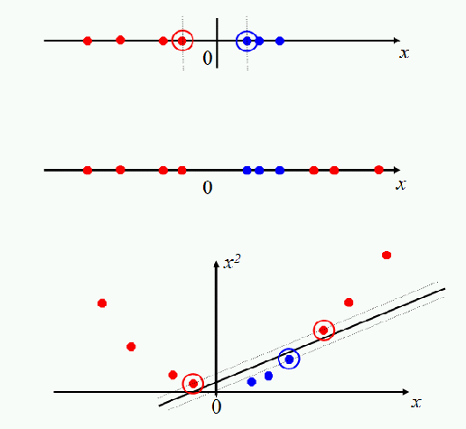

ISVM 4 IR

SVMs, and also a number of other linear classifiers, provide an easy and efficient way of doing this mapping to a higher dimensional space, which is referred to as “the kernel trick”. It’s not really a trick: it just exploits the math that we have seen. The SVM linear classifier relies on a dot product between data point vectors. Let $K(x, y) = \left<x, y\right> = x^Ty$. Then the classifier we have seen so far is

$$f(x) = {sign}(\sum_i \alpha_i d_i K(\vec{x}_i, \vec{x}) + b).$$

Now suppose we decide to map every data point into a higher dimensional space via some transformation $\Phi\colon {x} \mapsto\phi({x})$. Then the dot product becomes $\Phi(x)^T\Phi(y)$.

Kernel functions are sometimes more precisely referred to as Mercer kernels , because they must satisfy Mercer’s condition: for any $g(\vec{x})$ such that $\int g(\vec{x})^2 d\vec{x}$ is finite, we must have that:
$$\int K(\vec{x}, \vec{z})g(\vec{x})g(\vec{z})d\vec{x}d\vec{z} \ge 0\thinspace.$$

A kernel function $K$ must be continuous, symmetric, and have a positive definite gram matrix. Such a $K$ means that there exists a mapping to a reproducing kernel Hilbert space (a Hilbert space is a vector space closed under dot products) such that the dot product there gives the same value as the function $K$. If a kernel does not satisfy Mercer’s condition, then the corresponding QP may have no solution.

The most common form of radial basis function is a Gaussian distribution, calculated as:
$$K(\vec{x},\vec{z}) = e^{-\frac{(\vec{x}-\vec{z})^2}{2\sigma^2}}$$

The world of SVMs comes with its own language, which is rather different from the language otherwise used in machine learning. The terminology does have deep roots in mathematics, but it’s important not to be too awed by that terminology. Really, we are talking about some quite simple things. A polynomial kernel allows us to model feature conjunctions (up to the order of the polynomial). That is, if we want to be able to model occurrences of pairs of words, which give distinctive information about topic classification, not given by the individual words alone, like perhaps operating and system or ethnic and cleansing, then we need to use a quadratic kernel. If occurrences of triples of words give distinctive information, then we need to use a cubic kernel. Simultaneously you also get the powers of the basic features - for most text applications, that probably isn’t useful, but just comes along with the math and hopefully doesn’t do harm. A radial basis function allows you to have features that pick out circles (hyperspheres) - although the decision boundaries become much more complex as multiple such features interact. A string kernel lets you have features that are character subsequences of terms. All of these are straightforward notions which have also been used in many other places under different names.

- [Kernel method at Wikipedia](https://www.wikiwand.com/en/Kernel_method);
- http://www.kernel-machines.org/
- http://alex.smola.org/workshops.html
- http://onlineprediction.net/?n=Main.KernelMethods
- http://alex.smola.org/teaching/kernelcourse/
- https://arxiv.org/pdf/math/0701907.pdf
- https://www.ics.uci.edu/~welling/teaching/KernelsICS273B/svmintro.pdf
- https://people.eecs.berkeley.edu/~jordan/kernels.html
- https://nlp.stanford.edu/IR-book/html/htmledition/nonlinear-svms-1.html

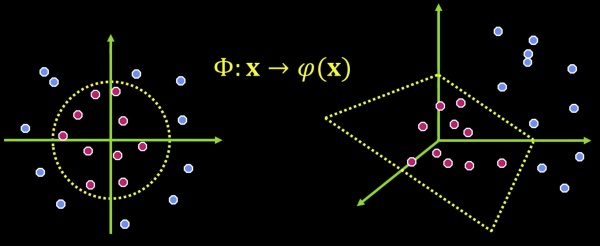

zhihu

If we apply the stacking ensemble methods to kernelized SVM, it is equivalent to deep learning or radical basis function network?

- http://www.ai.rug.nl/~mwiering/GROUP/ARTICLES/Multi-Layer-SVM.pdf
- http://mccormickml.com/2013/08/15/radial-basis-function-network-rbfn-tutorial/
- https://www.cc.gatech.edu/~isbell/tutorials/rbf-intro.pdf
- http://fourier.eng.hmc.edu/e161/lectures/nn/node11.html
- https://www.cs.cmu.edu/afs/cs/academic/class/15883-f15/slides/rbf.pdf